# 11-Tarea

Daniel Camarena

1. En este ejercicio usaremos los datos *threept*, éstos corresponden a lanzamientos para encestar canastas de 3 puntos, las variables *r* y *ángulo* indican la posición desde donde se lanzó el balón, siendo *r* la distancia entre el jugador y la canasta y *angle* el ángulo entre ellos.

```r
threept <- read.csv("threept.csv")
head(threept)
```

```
##               .id period                time team etype
## 1 20081028.PORLAL      1 2010-02-02 00:04:06  LAL  shot
## 2 20081028.PORLAL      1 2010-02-02 00:03:34  LAL  shot
## 3 20081028.PORLAL      1 2010-02-02 00:01:31  LAL  shot
## 4 20081028.PORLAL      1 2010-02-02 00:00:00  LAL  shot
## 5 20081028.PORLAL      2 2010-02-02 00:06:32  LAL  shot
## 6 20081028.PORLAL      2 2010-02-02 00:01:58  LAL  shot
##                player points result          x         y        r
## 1 Vladimir Radmanovic     NA missed  0.7527903  5.738697 24.91706
## 2          Lamar Odom     NA missed 40.5238888 25.705532 30.02941
## 3        Trevor Ariza      3   made 45.6325516 17.408215 26.99534
## 4       Sasha Vujacic     NA missed 37.4890770 30.476971 32.93665
## 5        Trevor Ariza      3   made 42.8808397 24.011976 29.93826
## 6 Vladimir Radmanovic      3   made  7.9488106 28.036978 32.81486
##       angle
## 1 166.68456
## 2  58.87170
## 3  40.15519
## 4  67.71680
## 5  53.32629
## 6 121.30662
```

- ¿La posición en la cancha influye en la probabilidad de éxito (encestar)? Piensa en una manera gráfica de visualizar esta pregunta y pruebala usando inferencia gráfica.

Separamos la grafica en dos: missed y made, graficando en cada una de ellas el angulo vs las distancia

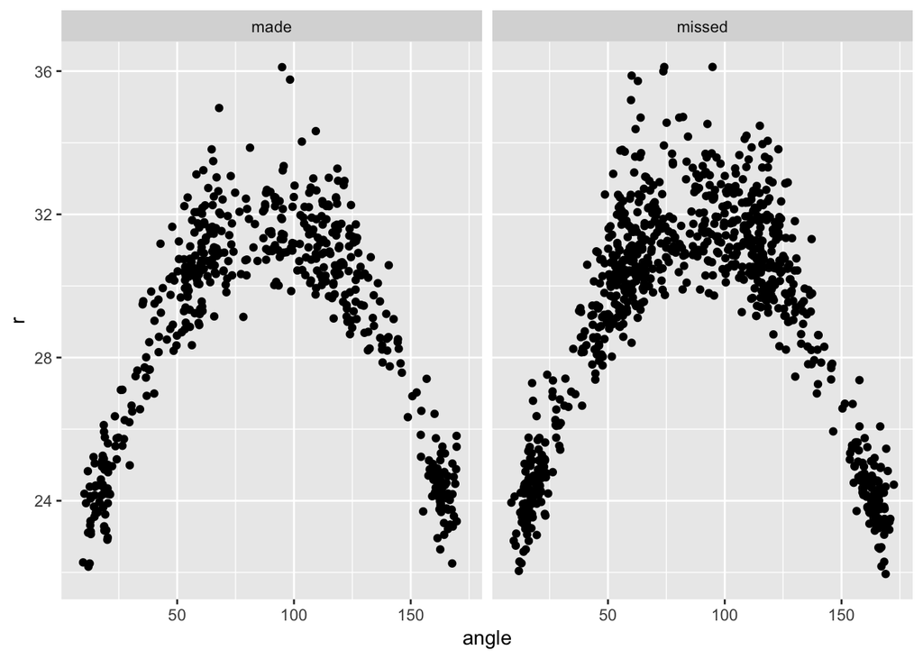

```r
threept %>%
  ggplot(aes(x = angle, y = r)) +
  geom_point() +
  facet_wrap(~result)
```

Usaremos el paquete nullabor para ver si la distancia del aro influye en el accurracy del tiro. Permutamos la variable result y graficamos

```r
null_threept <- lineup(null_permute("result"), threept)
```

```
## decrypt("WOXC 1IZI Tx t4nTZT4x iN")
```

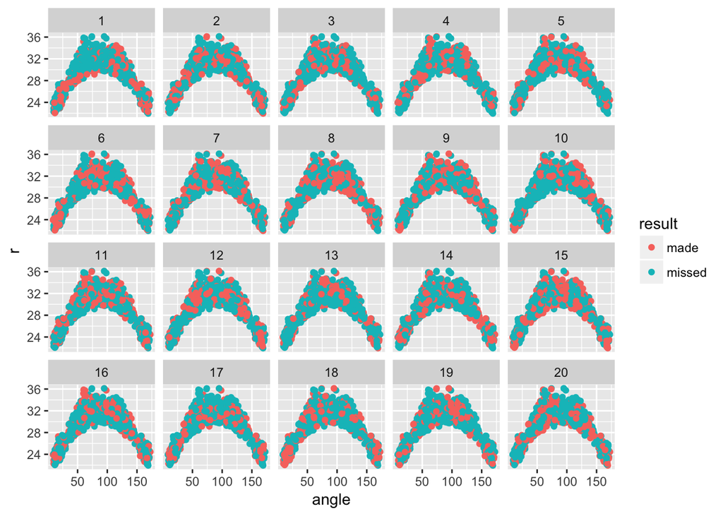

```r
null_threept %>%
  ggplot(aes(x = angle, y = r, color = result)) +
  geom_point() +
  facet_wrap(~.sample)
```

Como podemos ver, no es posible distinguir los datos reales de los simulados por el paquete nullabor, lo que nos lleva a concluír que no hay una relación entre la distancia al aro y el resultado del tiro.